# Sampling correction for large choice sets

1. Replicate synthetic data from Guevara & Ben-Akiva 2013
2. Do MNL with and without sampling correction
3. Check whether parameter estimates deviate from true values
4. Extend to Mixed Logit

## 1. Generate synthetic data set

- N = 1000 observations
- J = 1000 alternatives for all observations (C_n = C)
- X = single attribute distributed Uniform(-2,1) for the first 500 alternatives and Uniform(-1,2) for the second half
- beta = generic linear taste coefficient, distributed Normal(mu=1.5, sigma=0.8) across the 1000 observations
- systematic utility = beta * X
- epsilon = error term distributed ExtremeValue(0,1)
- random utility = beta * X + epsilon

Utility of alternative i for agent n: $$ U_{in} = V_{in} + \varepsilon_{in} = \beta_n x_{i} + \varepsilon_{in} $$

Probability that agent n will choose alternative i: $$ L_n(i \mid \beta_n, x_n,C_n) = \frac {e^{V_{in}}} {\sum_{j \epsilon C_n} e^{V_{jn}}} $$

```python
import numpy as np
import pandas as pd
```

```python
# Generate attribute x for each of J alternatives

# Start with J << 1000 to speed up runtimes

J = 50  # alternatives

# Set a seed for reproducibility
np.random.seed(12)

Xa = 3 * np.random.rand(J/2) - 2  # uniform distribution over [-2, 1]
Xb = 3 * np.random.rand(J/2) - 1  # uniform distribution over [-1, 2]

X = np.concatenate((Xa, Xb))

print len(X)
print X[:5]
```

```
50
[-1.53751147  0.22014909 -1.21005495 -0.39878182 -1.95627511]
```

```python
# Generate taste coefficient beta for each of N agents

# For regular MNL, i think we need to use a single value, instead of a
# distribution as Guevara & Ben-Akiva used for the mixture model

N = 1000  # agents/observations

beta = np.zeros(1000) + 1.5
# beta = 0.8 * np.random.randn(N) + 1.5

print len(beta)
print beta[:5]
```

```
1000
[ 1.5  1.5  1.5  1.5  1.5]
```

```python
print pd.DataFrame(beta).describe()
```

```
            0
count  1000.0
mean      1.5
std       0.0
min       1.5
25%       1.5
50%       1.5
75%       1.5
max       1.5
```

```python
# Generate probability matrix for N agents choosing among J alternatives

def probs(n):
    '''
    Return list of J probabilities for agent n
    '''
    b = beta[n]
    exps = [np.exp(b*x) for x in X]
    sum_exps = np.sum(exps)
    return [exp/sum_exps for exp in exps]

P = np.array([probs(n) for n in range(N)])

print P.shape
```

```
(1000, 50)
```

```python
# Check that each row sums to 1

print np.sum(P, axis=1)[:10]
```

```
[ 1.  1.  1.  1.  1.  1.  1.  1.  1.  1.]
```

```python
# Simulate a choice from J alternatives for each of N agents

C = [np.random.choice(range(J), p=p) for p in P]

print len(C)
print C[:10]
```

```
1000
[12, 41, 37, 5, 30, 27, 8, 35, 33, 6]
```

#### Now we have data:

- N agents/observations with true taste coefficients in array "beta"
- J alternatives with single attributes in array "X"
- N choice outcomes in array "C"

## 2. Estimate beta using PyLogit MNL

```python
import pylogit
from collections import OrderedDict
```

```python
# Set up an estimation dataset in long format

d = [[n, i, int(C[n]==i), X[i]] for i in range(J) for n in range(N)]

print len(d)
```

```
50000
```

```python
df = pd.DataFrame(d, columns=['obs_id', 'alt_id', 'choice', 'x'])

print df.describe()
```

```
             obs_id        alt_id        choice             x
count  50000.000000  50000.000000  50000.000000  50000.000000
mean     499.500000     24.500000      0.020000      0.014570
std      288.677877     14.431014      0.140001      1.116965
min        0.000000      0.000000      0.000000     -1.993222
25%      249.750000     12.000000      0.000000     -0.894495
50%      499.500000     24.500000      0.000000      0.220035
75%      749.250000     37.000000      0.000000      0.832675
max      999.000000     49.000000      1.000000      1.985414
```

```python
# Set up model spec

spec = OrderedDict([
        ('x', [range(J)])
    ])

labels = OrderedDict([
        ('x', ['beta_x'])
    ])
```

```python
m = pylogit.create_choice_model(data = df,
                                alt_id_col = 'alt_id',
                                obs_id_col = 'obs_id',
                                choice_col = 'choice',
                                specification = spec,
                                model_type = "MNL",
                                names = labels)

m.fit_mle(init_vals = np.array([0]))
print m.get_statsmodels_summary()
```

```
Log-likelihood at zero: -3,912.0230
Initial Log-likelihood: -3,912.0230
Estimation Time: 0.04 seconds.
Final log-likelihood: -3,065.1983
                     Multinomial Logit Model Regression Results
===================================================================================
Dep. Variable:                      choice   No. Observations:                1,000
Model:             Multinomial Logit Model   Df Residuals:                      999
Method:                                MLE   Df Model:                            1
Date:                     Tue, 15 Nov 2016   Pseudo R-squ.:                   0.216
Time:                             17:35:26   Pseudo R-bar-squ.:               0.216
converged:                            True   Log-Likelihood:             -3,065.198
                                             LL-Null:                    -3,912.023
==============================================================================
                 coef    std err          z      P>|z|      [95.0% Conf. Int.]
------------------------------------------------------------------------------
beta_x         1.5324        nan        nan        nan           nan       nan
==============================================================================
```

```python
m.hessian
```

|  | beta_x |
| --- | --- |
| beta_x | 5.826086e-13 |

Notes:

```python
# Use a more recent version of the mnl code for convenience
import integrated_mnl_2 as mnl_module

# Import libraries for plotting
import seaborn
import matplotlib.pyplot as plt

%matplotlib inline
```

```python
# Recreate the estimation object to use its convenient log-likelihood function
mnl_estimator = mnl_module.MNLEstimator(model_obj=m,
                                        mapping_dict=m.get_mappings_for_fit(),
                                        ridge=0,
                                        zero_vector=np.zeros(1),
                                        split_params=mnl_module.split_param_vec)
```

```python
# Create a function to plot the second order taylor series based on the
# estimated gradient and hessian, to see if the estimated values are correct
def plot_2nd_order_taylor_series(center_value,
                                 original_y,
                                 x_line,
                                 first_deriv,
                                 second_deriv,
                                 line_format_string="-k",
                                 line_label="2nd Order Taylor Series"):
    # Determine the value of each x minus the value
    # around which the series will be centered.
    diff_from_center = x_line - center_value
    # Create the "y-values" to be plotted
    y_vals = (original_y +
              first_deriv * (diff_from_center) +
              (second_deriv / 2.0) * np.square(diff_from_center))
    # Make the plot
    plt.plot(x_line, y_vals, line_format_string, label=line_label)

    return None
```

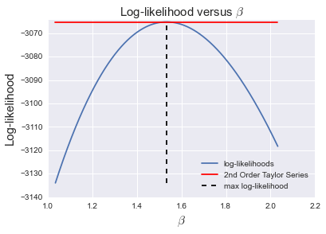

```python
# Plot the log likelihood as a function of beta, around the estimated value
estimated_beta = m.params.values[0]
interval_width = 0.5
beta_line = np.linspace(estimated_beta - interval_width,
                        estimated_beta + interval_width,
                        num=500)

log_likelihoods = [mnl_estimator.convenience_calc_log_likelihood(np.array(test_beta))
                   for test_beta in beta_line]

plt.plot(beta_line, log_likelihoods, label='log-likelihoods')
plt.vlines(estimated_beta,
           min(log_likelihoods),
           m.log_likelihood,
           linestyles='dashed',
           label='max log-likelihood')

# Plot a second order taylor series to see how well we estimated
# the hessian of the log-likelihood function
plot_2nd_order_taylor_series(estimated_beta,
                             m.log_likelihood,
                             beta_line,
                             m.gradient.values[0],
                             m.hessian.values[0, 0],
                             line_format_string='-r')

plt.legend(loc='best')
plt.xlabel(r"$\beta$", fontsize=15)
plt.ylabel("Log-likelihood", fontsize=15)
plt.title(r"Log-likelihood versus $\beta$", fontsize=15)
plt.ylim(ymax=m.log_likelihood + 1)
plt.show()
```

Clearly we've done a poor job.

# Why is the hessian being calculated incorrectly?

### First, how should the Hessian be calculated?

Note that

1. the design matrix only consists of variables that remain constant across the dataset
2. the coefficients are constant across the population
3. the choice set is constant across individuals As a result of all of this, the estimated probabilities of choosing each alternative will be the same for each person.

Now, the hessian is the sum of the second derivatives of the log-likelihood for each observation. So we should N * hessian_1 where hessian_1 is the second derivative of the log-likelihood for the first observation.

```python
# Get the estimated probabilities of choosing each alternative
# This will be constant across individuals
estimated_probs = [m.long_fitted_probs[N * idx]for idx in range(J)]
estimated_probs

# Calculate the derivative of the probabilities with respect
# to s = X*B
dp_ds = np.diag(estimated_probs) - np.outer(estimated_probs,
                                            estimated_probs)

# Calculate the hessian for a single observation
hessian_1 = (-1 * X[None, :]).dot(dp_ds.dot(X[:, None]))

# Calculate the hessian for the entire dataset that we expect
# recover. Note this multiplication only works because of the
# special set up of this simulation/residential choice problem
expected_hessian = N * hessian_1
print "The hessian we expect to see is:", expected_hessian

# Calculate the standard error that we expect for this dataset
expected_std_error = np.diag(np.linalg.inv(-1 *
                                           expected_hessian))**0.5
print "The standard error we expect to see is:", expected_std_error
```

```
The hessian we expect to see is: [[-482.17324461]]
The standard error we expect to see is: [ 0.04554057]
```

### Now, what is wrong with the current hessian calculation?

Long story short, the matrix equations I use to calculate the hessian create blocks of dp_ds, therefore the matrices that multiply and are multiplied by dp_ds should have continuous columns (rows) for a given observation. The simulation data from Sam does not meet this criteria, and I do not have a warning for the user for this criteria. Essentially, the input data should place all rows for a given observation together.

```python
# Get the mapping matrices from the first model object
mapping_matrices = m.get_mappings_for_fit()

# Order the dataframe in order of it's observation ids
sub_dfs = [df.loc[indices] for indices in
           pylogit.choice_calcs.create_matrix_block_indices(mapping_matrices["rows_to_obs"])]
ordered_df = pd.concat(sub_dfs, axis=0, ignore_index=True)
```

```python
m2 = pylogit.create_choice_model(data = ordered_df,
                                alt_id_col = 'alt_id',
                                obs_id_col = 'obs_id',
                                choice_col = 'choice',
                                specification = spec,
                                model_type = "MNL",
                                names = labels)

m2.fit_mle(init_vals = np.array([0]))
print m2.get_statsmodels_summary()
```

```
Log-likelihood at zero: -3,912.0230
Initial Log-likelihood: -3,912.0230
Estimation Time: 0.04 seconds.
Final log-likelihood: -3,065.1983
                     Multinomial Logit Model Regression Results
===================================================================================
Dep. Variable:                      choice   No. Observations:                1,000
Model:             Multinomial Logit Model   Df Residuals:                      999
Method:                                MLE   Df Model:                            1
Date:                     Tue, 15 Nov 2016   Pseudo R-squ.:                   0.216
Time:                             17:35:41   Pseudo R-bar-squ.:               0.216
converged:                            True   Log-Likelihood:             -3,065.198
                                             LL-Null:                    -3,912.023
==============================================================================
                 coef    std err          z      P>|z|      [95.0% Conf. Int.]
------------------------------------------------------------------------------
beta_x         1.5324      0.046     33.649      0.000         1.443     1.622
==============================================================================
```

## Try with UrbanSim MNL instead of PyLogit

Model class: https://github.com/UDST/urbansim/blob/master/urbansim/models/dcm.py

Estimation algorithms: https://github.com/UDST/urbansim/blob/master/urbansim/urbanchoice/mnl.py

```python
from urbansim.models import MNLDiscreteChoiceModel
```

```python
# Choosers should be a DataFrame of characteristics, with index as identifier

d = [[n, C[n]] for n in range(N)]

choosers = pd.DataFrame(d, columns=['id', 'choice']).set_index('id')

print len(choosers)
```

```
1000
```

```python
# Alternatives should be a DataFrame of characteristics, with index as identifier

d = [[i, X[i]] for i in range(J)]

alts = pd.DataFrame(d, columns=['id', 'x']).set_index('id')

print len(alts)
```

[output not shown]

```python
# It seems like this implementation *requires* us to sample the alternatives,
# so here i'm estimating the model with J-1 alts

m = MNLDiscreteChoiceModel(model_expression = 'x',
                           sample_size = J-1)

m.fit(choosers = choosers,
      alternatives = alts,
      current_choice = 'choice')

m.report_fit()
```

[output not shown]

```python
# To do
# - look through PyLogit and LCCM code
# - in many-alternative scenarios, attirbutes of the alternatives will
#   usually be in a separate data table - what helper functions do we need?
```